# ISL Chapter 4: Lab & Applied Exercises

Momoko Price

04/05/2020

#### 4.6 Lab: Logistic Regression, LDA, QDA, and KNN

##### 4.6.1 The Stock Market Data

We will begin by examining some numerical and graphical summaries of the Smarket data, which is part of the ISLR library. This data set consists of percentage returns for the S&P 500 stock index over 1, 250 days, from the beginning of 2001 until the end of 2005. For each date, we have recorded the percentage returns for each of the five previous trading days, Lag1 through Lag5. We have also recorded Volume (the number of shares traded on the previous day, in billions), Today (the percentage return on the date in question) and Direction (whether the market was Up or Down on this date).

```r
# check structure
str(Smarket)
```

```
## 'data.frame':    1250 obs. of  9 variables:
##  $ Year     : num  2001 2001 2001 2001 2001 ...
##  $ Lag1     : num  0.381 0.959 1.032 -0.623 0.614 ...
##  $ Lag2     : num  -0.192 0.381 0.959 1.032 -0.623 ...
##  $ Lag3     : num  -2.624 -0.192 0.381 0.959 1.032 ...
##  $ Lag4     : num  -1.055 -2.624 -0.192 0.381 0.959 ...
##  $ Lag5     : num  5.01 -1.055 -2.624 -0.192 0.381 ...
##  $ Volume   : num  1.19 1.3 1.41 1.28 1.21 ...
##  $ Today    : num  0.959 1.032 -0.623 0.614 0.213 ...
##  $ Direction: Factor w/ 2 levels "Down","Up": 2 2 1 2 2 2 1 2 2 2 ...
```

```r
# check max/min & quantiles of each variable
summary(Smarket)
```

```
##       Year           Lag1                Lag2                Lag3
##  Min.   :2001   Min.   :-4.922000   Min.   :-4.922000   Min.   :-4.922000
##  1st Qu.:2002   1st Qu.:-0.639500   1st Qu.:-0.639500   1st Qu.:-0.640000
##  Median :2003   Median : 0.039000   Median : 0.039000   Median : 0.038500
##  Mean   :2003   Mean   : 0.003834   Mean   : 0.003919   Mean   : 0.001716
##  3rd Qu.:2004   3rd Qu.: 0.596750   3rd Qu.: 0.596750   3rd Qu.: 0.596750
##  Max.   :2005   Max.   : 5.733000   Max.   : 5.733000   Max.   : 5.733000
##       Lag4                Lag5              Volume           Today
##  Min.   :-4.922000   Min.   :-4.92200   Min.   :0.3561   Min.   :-4.922000
##  1st Qu.:-0.640000   1st Qu.:-0.64000   1st Qu.:1.2574   1st Qu.:-0.639500
##  Median : 0.038500   Median : 0.03850   Median :1.4229   Median : 0.038500
##  Mean   : 0.001636   Mean   : 0.00561   Mean   :1.4783   Mean   : 0.003138
##  3rd Qu.: 0.596750   3rd Qu.: 0.59700   3rd Qu.:1.6417   3rd Qu.: 0.596750
##  Max.   : 5.733000   Max.   : 5.73300   Max.   :3.1525   Max.   : 5.733000
##  Direction
##  Down:602
##  Up  :648
##
##
##
##
```

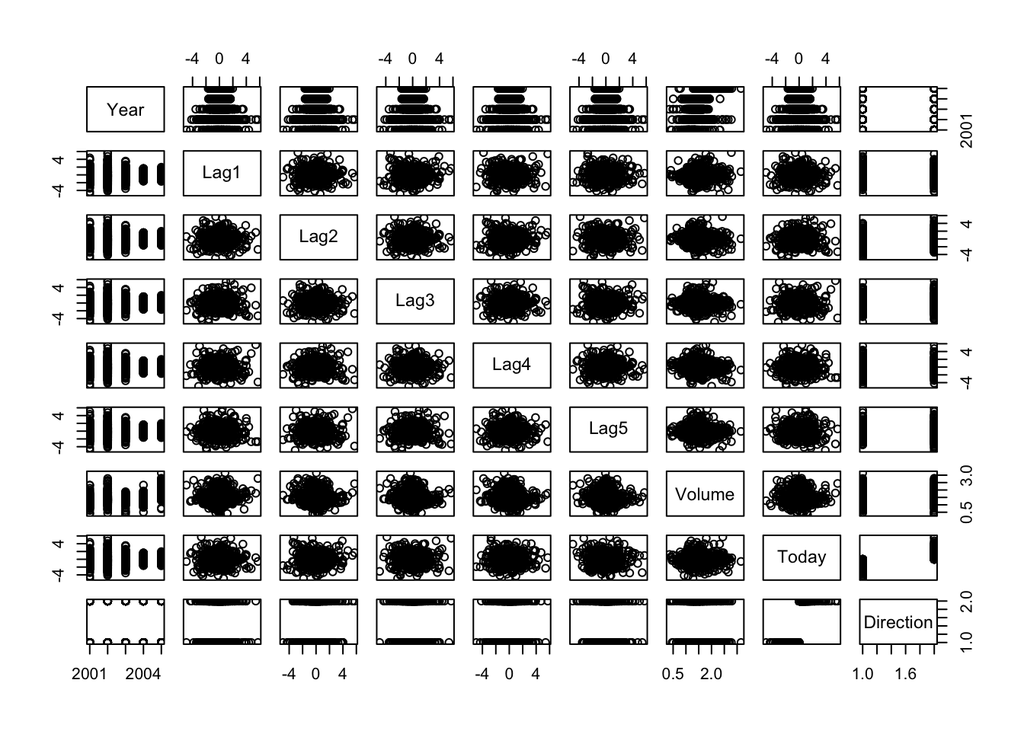

```r
# facet the variables against one another & look for trends
pairs(Smarket)
```

```r
# check for correlations (remove 'Direction' var bc it's qualitative)
cor(Smarket[,-9])
```

```
##              Year         Lag1         Lag2         Lag3         Lag4
## Year   1.00000000  0.029699649  0.030596422  0.033194581  0.035688718
## Lag1   0.02969965  1.000000000 -0.026294328 -0.010803402 -0.002985911
## Lag2   0.03059642 -0.026294328  1.000000000 -0.025896670 -0.010853533
## Lag3   0.03319458 -0.010803402 -0.025896670  1.000000000 -0.024051036
## Lag4   0.03568872 -0.002985911 -0.010853533 -0.024051036  1.000000000
## Lag5   0.02978799 -0.005674606 -0.003557949 -0.018808338 -0.027083641
## Volume 0.53900647  0.040909908 -0.043383215 -0.041823686 -0.048414246
## Today  0.03009523 -0.026155045 -0.010250033 -0.002447647 -0.006899527
##                Lag5      Volume        Today
## Year    0.029787995  0.53900647  0.030095229
## Lag1   -0.005674606  0.04090991 -0.026155045
## Lag2   -0.003557949 -0.04338321 -0.010250033
## Lag3   -0.018808338 -0.04182369 -0.002447647
## Lag4   -0.027083641 -0.04841425 -0.006899527
## Lag5    1.000000000 -0.02200231 -0.034860083
## Volume -0.022002315  1.00000000  0.014591823
## Today  -0.034860083  0.01459182  1.000000000
```

Sort the correlations and see which variables have the strongest correlations:

```r
# convert to dataframe
corr <- as.data.frame(cor(Smarket[,-9]))
# turn rownames into a variable
setDT(corr, keep.rownames = "var1")
# gather corrs into single column
corr_tidy <- corr %>%
  pivot_longer(c(2:9), names_to = "var2", values_to = "corr") %>%
  # remove self-correlations
  filter(corr != 1) %>%
  # sort from highest to lowest
  arrange(desc(corr))
# remove even rows (duplicates)
toDelete <- seq(1, nrow(corr_tidy), 2)
corrs <- corr_tidy[-toDelete, ]
head(corrs, 9)
```

```
## # A tibble: 9 x 3
##   var1   var2     corr
##   <chr>  <chr>   <dbl>
## 1 Volume Year   0.539
## 2 Volume Lag1   0.0409
## 3 Lag4   Year   0.0357
## 4 Lag3   Year   0.0332
## 5 Lag2   Year   0.0306
## 6 Today  Year   0.0301
## 7 Lag5   Year   0.0298
## 8 Lag1   Year   0.0297
## 9 Today  Volume 0.0146
```

There isn’t much of an association between any variable except year and volume. Let’s see what that looks like:

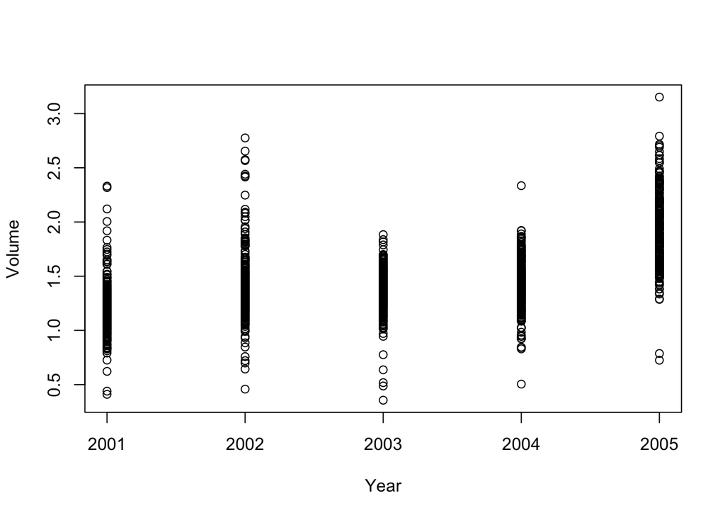

```r
plot(Smarket$Year, Smarket$Volume, xlab = "Year", ylab = "Volume")
```

##### 4.6.2 Logistic Regression

Next, we will fit a logistic regression model in order to predict Direction using Lag1 through Lag5 and Volume. The glm() function fits generalized linear models, a class of models that includes logistic regression. The syntax of the glm() function is similar to that of lm(), except that we must pass in the argument family=binomial in order to tell R to run a logistic regression rather than some other type of generalized linear model.

```r
# predict direction based on lag variables and trade volume
stock.1 <- glm(Direction ~ . -Year -Today, data = Smarket, family = binomial)
summary(stock.1)
```

```
##
## Call:
## glm(formula = Direction ~ . - Year - Today, family = binomial,
##     data = Smarket)
##
## Deviance Residuals:
##    Min      1Q  Median      3Q     Max
## -1.446  -1.203   1.065   1.145   1.326
##
## Coefficients:
##              Estimate Std. Error z value Pr(>|z|)
## (Intercept) -0.126000   0.240736  -0.523    0.601
## Lag1        -0.073074   0.050167  -1.457    0.145
## Lag2        -0.042301   0.050086  -0.845    0.398
## Lag3         0.011085   0.049939   0.222    0.824
## Lag4         0.009359   0.049974   0.187    0.851
## Lag5         0.010313   0.049511   0.208    0.835
## Volume       0.135441   0.158360   0.855    0.392
##
## (Dispersion parameter for binomial family taken to be 1)
##
##     Null deviance: 1731.2  on 1249  degrees of freedom
## Residual deviance: 1727.6  on 1243  degrees of freedom
## AIC: 1741.6
##
## Number of Fisher Scoring iterations: 3
```

According to this model, there is no significant relationship between the outcome (direction of the stock on a given date) and the % change of any of the previous 5 days.

```r
stock.1.probs <- predict(stock.1, type="response")
stock.1.probs[1:10]
```

```
##         1         2         3         4         5         6         7         8
## 0.5070841 0.4814679 0.4811388 0.5152224 0.5107812 0.5069565 0.4926509 0.5092292
##         9        10
## 0.5176135 0.4888378
```

```r
# change prob values to clear 'up' or 'down' values
# first make a vector of 'down' values the same length as the Smarket sample
len <- length(Smarket)
stock.1.preds <- rep("Down", 1250)
stock.1.preds[stock.1.probs > .5] ="Up"
stock.1.preds[1:10]
```

```
##  [1] "Up"   "Down" "Down" "Up"   "Up"   "Up"   "Down" "Up"   "Up"   "Down"
```

How do the predictions from our model compare with the actual direction values for the Smarket dataset? We can use the ‘table’ function to create a confusion matrix that compares the number of days whose directions were correctly predicted vs those that weren’t.

```r
# create confusion matrix
table(stock.1.preds, Smarket$Direction)
```

```
##
## stock.1.preds Down  Up
##          Down  145 141
##          Up    457 507
```

```r
# calculate the % of correct predictions using the mean() function
mean(stock.1.preds == Smarket$Direction)
```

```
## [1] 0.5216
```

```r
# calculate the % of incorrect predictions using the mean() function
mean(stock.1.preds != Smarket$Direction)
```

```
## [1] 0.4784
```

This looks like it might be a little better than random, but remember it’s the training error rate, not the testing error rate! To get a better estimate of model predictability, what you’d need to do is set aside a sample of data that won’t be included in building the model and then use that to generate model outcomes based on the sample’s predictors and check how accurate they are, like so:

```r
# create a vector of logical values that label each obs as either before (T) or during (F) 2005
train <- (Smarket$Year < 2005)
test <- (Smarket$Year == 2005)
# use this to create a subset of Smarket data that's only those IN 2005
Smarket.2005 <- Smarket[test,]
# create a single-var vector of test predictions from this data
Direction.2005 <- Smarket.2005$Direction
```

Now we set a new model using ONLY data from before 2005 (i.e. our training data), like so:

```r
# create the model (i.e. "train")
pre2005.fit <- glm(Direction ~ . -Today -Year, data=Smarket, family=binomial, subset=train)
# generate predictions from the model(i.e. "test")
pre2005.fit.probs <- predict(pre2005.fit, Smarket.2005, type="response")
# convert to qualitative labels ("Up", "Down")
pre2005.fit.preds <- rep("Down", 252)
pre2005.fit.preds[pre2005.fit.probs >0.5] <- "Up"
table(pre2005.fit.preds, Direction.2005)
```

```
##                  Direction.2005
## pre2005.fit.preds Down Up
##              Down   77 97
##              Up     34 44
```

```r
mean(pre2005.fit.preds == Direction.2005)
```

```
## [1] 0.4801587
```

This model has an accuracy of less than 50% (or a test error rate of 52%) - not great! How can we improve this model? One way would be to remove the predictors with the highest p values. Let’s see what happens if we do this.

```r
# identify the higher p-values
summary(pre2005.fit)
```

```
##
## Call:
## glm(formula = Direction ~ . - Today - Year, family = binomial,
##     data = Smarket, subset = train)
##
## Deviance Residuals:
##    Min      1Q  Median      3Q     Max
## -1.302  -1.190   1.079   1.160   1.350
##
## Coefficients:
##              Estimate Std. Error z value Pr(>|z|)
## (Intercept)  0.191213   0.333690   0.573    0.567
## Lag1        -0.054178   0.051785  -1.046    0.295
## Lag2        -0.045805   0.051797  -0.884    0.377
## Lag3         0.007200   0.051644   0.139    0.889
## Lag4         0.006441   0.051706   0.125    0.901
## Lag5        -0.004223   0.051138  -0.083    0.934
## Volume      -0.116257   0.239618  -0.485    0.628
##
## (Dispersion parameter for binomial family taken to be 1)
##
##     Null deviance: 1383.3  on 997  degrees of freedom
## Residual deviance: 1381.1  on 991  degrees of freedom
## AIC: 1395.1
##
## Number of Fisher Scoring iterations: 3
```

```r
# train new model only using Lag1 and Lag2 as predictors
lag1lag2.fit <- glm(Direction ~ Lag1 + Lag2, data = Smarket, family = binomial, subset = train)
# test new model with test data
lag1lag2.fit.probs <- predict(lag1lag2.fit, Smarket.2005, type="response")
# convert to qual values
lag1lag2.fit.preds <- rep("Down", length(Smarket.2005))
lag1lag2.fit.preds[lag1lag2.fit.probs > 0.5] <- "Up"
lag1lag2.fit.preds[lag1lag2.fit.probs <= 0.5] <- "Down"
# create confusion matrix to gauge error rate (predictions vs. test data)
table(lag1lag2.fit.preds, Direction.2005)
```

```
##                   Direction.2005
## lag1lag2.fit.preds Down  Up
##               Down   35  35
##               Up     76 106
```

```r
mean(lag1lag2.fit.preds != Direction.2005)
```

```
## [1] 0.4404762
```

Test error rate is slightly better, but not great. But better than before! Using this model, let’s use the predict function to actually make a prediction of what the stock direction would be given an exact-value vector of predictors.

```r
# test new model with an exact-value vector
exact.probs <- predict(lag1lag2.fit, newdata= data.frame(Lag1 = c(1.2, 1.5), Lag2 = c(1.1, -0.8)), type="response")
# convert to qual values
exact.preds <- rep("Down", length(exact.probs))
exact.preds[exact.probs > 0.5] <- "Up"
```

##### 4.6.3 Linear Discriminant Analysis

Let’s now try building a predictive model on the Smarket data (just using Lag1 and Lag2 as predictors), using Linear Discriminant Analysis:

```r
# train model with pre2005 data, using the subset function and the 'train' vector
lda.fit <- lda(Direction ~ Lag1 + Lag2, data=Smarket, subset=train)
# note that for LDA you don't have to use 'summary' to get the analysis
lda.fit
```

```
## Call:
## lda(Direction ~ Lag1 + Lag2, data = Smarket, subset = train)
##
## Prior probabilities of groups:
##     Down       Up
## 0.491984 0.508016
##
## Group means:
##             Lag1        Lag2
## Down  0.04279022  0.03389409
## Up   -0.03954635 -0.03132544
##
## Coefficients of linear discriminants:
##             LD1
## Lag1 -0.6420190
## Lag2 -0.5135293
```

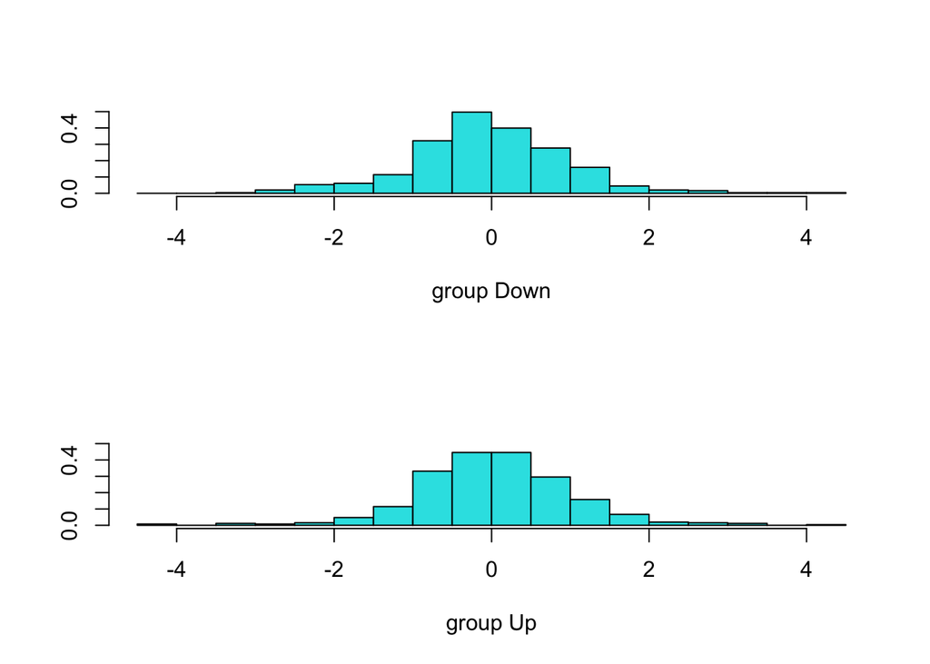

```r
# plot the linear discriminants, which means the histogram distributions of y values with the linear discriminant function of y = -0.642*Lag1-0.514*Lag2.
plot(lda.fit)
```

The LDA plot gives us a general perspective of how distinct th distribution of training values are between the two classes, using the linear model we’ve built using Lag1 and Lag2 as our predictors. (Clearly there is not much of a difference between the two, but the distribution of down values is lower overall than that of the up values.)

Let’s now test the model using our test data:

```r
lda.pred.values <- predict(lda.fit, Smarket.2005)
lda.preds <- lda.pred.values$class
table(lda.preds, Direction.2005)
```

```
##          Direction.2005
## lda.preds Down  Up
##      Down   35  35
##      Up     76 106
```

```r
mean(lda.preds == Direction.2005)
```

```
## [1] 0.5595238
```

Note that ‘posterior probability’ refers to the probability of an outcome/prediction GIVEN a specific set of predictors.

##### 4.6.4 Quadratic Discriminant Analysis

QDA is basically the same as LDA in concept, it just has less bias, which allows for better fitting, but leaves it vulnerable to overfitting as well. Let’s fit the Smarket data to a QDA model and see how accurately it predicts:

```r
qda.fit <- qda(Direction ~ Lag1 + Lag2, data=Smarket, subset=train)
qda.fit
```

```
## Call:
## qda(Direction ~ Lag1 + Lag2, data = Smarket, subset = train)
##
## Prior probabilities of groups:
##     Down       Up
## 0.491984 0.508016
##
## Group means:
##             Lag1        Lag2
## Down  0.04279022  0.03389409
## Up   -0.03954635 -0.03132544
```

```r
qda.preds <- predict(qda.fit, Smarket.2005)$class
table(qda.preds, Direction.2005)
```

```
##          Direction.2005
## qda.preds Down  Up
##      Down   30  20
##      Up     81 121
```

```r
mean(qda.preds == Direction.2005)
```

```
## [1] 0.5992063
```

##### 4.6.5 K-Nearest Neighbours

We will now perform KNN using the knn() function, which is part of the class library. This function works rather differently from the other model- fitting functions that we have encountered thus far. Rather than a two-step approach in which we first fit the model and then we use the model to make predictions, knn() forms predictions using a single command, and requires four inputs.

```r
# set up your data - first the matrix of predictors (which will get split into training and testing subsets when input into the knn model)
Smarket.knn <- cbind(Smarket$Lag1, Smarket$Lag2)
# next, your vector of training outcomes
Direction.pre2005 <- Smarket$Direction[train]

set.seed(1)
# order of inputs: training predictors, test predictors, training outcomes, # of nearest neighbours
# output of knn is just a vector of predicted outcomes
knn.pred <- knn(Smarket.knn[train,],
                Smarket.knn[!train,],
                Direction.pre2005,
                k=1)
# test the accuracy against the test outcomes
table(knn.pred, Direction.2005)
```

```
##         Direction.2005
## knn.pred Down Up
##     Down   43 58
##     Up     68 83
```

```r
mean(knn.pred == Direction.2005)
```

```
## [1] 0.5
```

Hm, the accuracy of the predictions are clearly pretty garbage (same as random). Let’s try increasing the # of nearest neighbours to 3 and see what happens

```r
knn.pred.k3 <- knn(Smarket.knn[train,],
                Smarket.knn[!train,],
                Direction.pre2005,
                k=3)
# test the accuracy against the test outcomes
table(knn.pred.k3, Direction.2005)
```

```
##            Direction.2005
## knn.pred.k3 Down Up
##        Down   48 54
##        Up     63 87
```

```r
mean(knn.pred.k3 == Direction.2005)
```

```
## [1] 0.5357143
```

##### 4.6.6 An Application to Caravan Insurance Data

Finally, we will apply the KNN approach to the Caravan data set, which is part of the ISLR library. This data set includes 85 predictors that measure demographic characteristics for 5,822 individuals. The response variable is Purchase, which indicates whether or not a given individual purchases a caravan insurance policy. In this data set, only 6% of people purchased caravan insurance.

```r
# check structure
str(Caravan)
```

```
## 'data.frame':    5822 obs. of  86 variables:
##  $ MOSTYPE : num  33 37 37 9 40 23 39 33 33 11 ...
##  $ MAANTHUI: num  1 1 1 1 1 1 2 1 1 2 ...
##  $ MGEMOMV : num  3 2 2 3 4 2 3 2 2 3 ...
##  $ MGEMLEEF: num  2 2 2 3 2 1 2 3 4 3 ...
##  $ MOSHOOFD: num  8 8 8 3 10 5 9 8 8 3 ...
##  $ MGODRK  : num  0 1 0 2 1 0 2 0 0 3 ...
##  $ MGODPR  : num  5 4 4 3 4 5 2 7 1 5 ...
##  $ MGODOV  : num  1 1 2 2 1 0 0 0 3 0 ...
##  $ MGODGE  : num  3 4 4 4 4 5 5 2 6 2 ...
##  $ MRELGE  : num  7 6 3 5 7 0 7 7 6 7 ...
##  $ MRELSA  : num  0 2 2 2 1 6 2 2 0 0 ...
##  $ MRELOV  : num  2 2 4 2 2 3 0 0 3 2 ...
##  $ MFALLEEN: num  1 0 4 2 2 3 0 0 3 2 ...
##  $ MFGEKIND: num  2 4 4 3 4 5 3 5 3 2 ...
```

[output cut: 72 more lines]

```r
# check max/min & quantiles of each variable
summary(Caravan)
```

```
##     MOSTYPE         MAANTHUI         MGEMOMV         MGEMLEEF
##  Min.   : 1.00   Min.   : 1.000   Min.   :1.000   Min.   :1.000
##  1st Qu.:10.00   1st Qu.: 1.000   1st Qu.:2.000   1st Qu.:2.000
##  Median :30.00   Median : 1.000   Median :3.000   Median :3.000
##  Mean   :24.25   Mean   : 1.111   Mean   :2.679   Mean   :2.991
##  3rd Qu.:35.00   3rd Qu.: 1.000   3rd Qu.:3.000   3rd Qu.:3.000
##  Max.   :41.00   Max.   :10.000   Max.   :5.000   Max.   :6.000
##     MOSHOOFD          MGODRK           MGODPR          MGODOV
##  Min.   : 1.000   Min.   :0.0000   Min.   :0.000   Min.   :0.00
##  1st Qu.: 3.000   1st Qu.:0.0000   1st Qu.:4.000   1st Qu.:0.00
##  Median : 7.000   Median :0.0000   Median :5.000   Median :1.00
##  Mean   : 5.774   Mean   :0.6965   Mean   :4.627   Mean   :1.07
##  3rd Qu.: 8.000   3rd Qu.:1.0000   3rd Qu.:6.000   3rd Qu.:2.00
##  Max.   :10.000   Max.   :9.0000   Max.   :9.000   Max.   :5.00
##      MGODGE          MRELGE          MRELSA           MRELOV
##  Min.   :0.000   Min.   :0.000   Min.   :0.0000   Min.   :0.00
##  1st Qu.:2.000   1st Qu.:5.000   1st Qu.:0.0000   1st Qu.:1.00
##  Median :3.000   Median :6.000   Median :1.0000   Median :2.00
##  Mean   :3.259   Mean   :6.183   Mean   :0.8835   Mean   :2.29
##  3rd Qu.:4.000   3rd Qu.:7.000   3rd Qu.:1.0000   3rd Qu.:3.00
##  Max.   :9.000   Max.   :9.000   Max.   :7.0000   Max.   :9.00
##     MFALLEEN        MFGEKIND       MFWEKIND      MOPLHOOG        MOPLMIDD
##  Min.   :0.000   Min.   :0.00   Min.   :0.0   Min.   :0.000   Min.   :0.000
##  1st Qu.:0.000   1st Qu.:2.00   1st Qu.:3.0   1st Qu.:0.000   1st Qu.:2.000
##  Median :2.000   Median :3.00   Median :4.0   Median :1.000   Median :3.000
##  Mean   :1.888   Mean   :3.23   Mean   :4.3   Mean   :1.461   Mean   :3.351
##  3rd Qu.:3.000   3rd Qu.:4.00   3rd Qu.:6.0   3rd Qu.:2.000   3rd Qu.:4.000
##  Max.   :9.000   Max.   :9.00   Max.   :9.0   Max.   :9.000   Max.   :9.000
##     MOPLLAAG        MBERHOOG        MBERZELF        MBERBOER
##  Min.   :0.000   Min.   :0.000   Min.   :0.000   Min.   :0.0000
##  1st Qu.:3.000   1st Qu.:0.000   1st Qu.:0.000   1st Qu.:0.0000
##  Median :5.000   Median :2.000   Median :0.000   Median :0.0000
##  Mean   :4.572   Mean   :1.895   Mean   :0.398   Mean   :0.5223
##  3rd Qu.:6.000   3rd Qu.:3.000   3rd Qu.:1.000   3rd Qu.:1.0000
##  Max.   :9.000   Max.   :9.000   Max.   :5.000   Max.   :9.0000
##     MBERMIDD        MBERARBG       MBERARBO          MSKA           MSKB1
##  Min.   :0.000   Min.   :0.00   Min.   :0.000   Min.   :0.000   Min.   :0.000
##  1st Qu.:2.000   1st Qu.:1.00   1st Qu.:1.000   1st Qu.:0.000   1st Qu.:1.000
##  Median :3.000   Median :2.00   Median :2.000   Median :1.000   Median :2.000
##  Mean   :2.899   Mean   :2.22   Mean   :2.306   Mean   :1.621   Mean   :1.607
```

[output cut: 92 more lines]

```
##  Max.   :8.00000   Max.   :1.000000   Max.   :1.000000   Max.   :2.000000
##      ABRAND          AZEILPL             APLEZIER            AFIETS
##  Min.   :0.0000   Min.   :0.0000000   Min.   :0.000000   Min.   :0.00000
##  1st Qu.:0.0000   1st Qu.:0.0000000   1st Qu.:0.000000   1st Qu.:0.00000
##  Median :1.0000   Median :0.0000000   Median :0.000000   Median :0.00000
##  Mean   :0.5701   Mean   :0.0005153   Mean   :0.006012   Mean   :0.03178
##  3rd Qu.:1.0000   3rd Qu.:0.0000000   3rd Qu.:0.000000   3rd Qu.:0.00000
##  Max.   :7.0000   Max.   :1.0000000   Max.   :2.000000   Max.   :3.00000
##     AINBOED            ABYSTAND       Purchase
##  Min.   :0.000000   Min.   :0.00000   No :5474
##  1st Qu.:0.000000   1st Qu.:0.00000   Yes: 348
##  Median :0.000000   Median :0.00000
##  Mean   :0.007901   Mean   :0.01426
##  3rd Qu.:0.000000   3rd Qu.:0.00000
##  Max.   :2.000000   Max.   :2.00000
```

```r
# facet the variables against one another & look for trends
## pairs(Caravan) - don't bother, too many plots to fit space
# check for correlations (remove 'Purchase' var bc it's qualitative)
cors <- as.data.frame(cor(Caravan[,-86]))
# Sort the correlations and see which variables have the strongest correlations:
# turn rownames into a variable
setDT(cors, keep.rownames = "var1")
# gather corrs into single column
cors_tidy <- cors %>%
  pivot_longer(c(2:86), names_to = "var2", values_to = "cors") %>%
  # remove self-correlations
 filter(cors != 1) %>%
# sort from highest to lowest
  arrange(desc(cors))
# remove even rows (duplicates)
toDelete <- seq(1, nrow(cors_tidy), 2)
cors <- cors_tidy[-toDelete, ]
head(cors, 9)
```

```
## # A tibble: 9 x 3
##   var1     var2      cors
##   <chr>    <chr>    <dbl>
## 1 MOSHOOFD MOSTYPE  0.993
## 2 AWALAND  PWALAND  0.988
## 3 AWAPART  PWAPART  0.981
## 4 AGEZONG  PGEZONG  0.980
## 5 ABROM    PBROM    0.970
## 6 ABYSTAND PBYSTAND 0.966
## 7 AAANHANG PAANHANG 0.966
## 8 AVRAAUT  PVRAAUT  0.949
## 9 AWAOREG  PWAOREG  0.948
```

```r
tail(cors, 9)
```

```
## # A tibble: 9 x 3
##   var1     var2       cors
##   <chr>    <chr>     <dbl>
## 1 MINKGEM  MINKM30  -0.646
## 2 MFALLEEN MGEMOMV  -0.660
## 3 MFALLEEN MRELGE   -0.684
## 4 MAUT0    MAUT1    -0.735
## 5 MGODGE   MGODPR   -0.742
## 6 MOPLLAAG MOPLMIDD -0.748
## 7 MRELOV   MRELGE   -0.884
## 8 MZPART   MZFONDS  -0.999
## 9 MHKOOP   MHHUUR   -1.00
```

```r
# how many people actually purchased a caravan?
purchased <- summary(Caravan$Purchase)[['Yes']]
# get the conversion rate
purchased/nrow(Caravan)
```

```
## [1] 0.05977327
```

Well that initial exploration shows us that some predictors are HIGHLY correlated, both positively and negatively. Won’t do anything about that now. Let’s prep the data for KNN, given that the variable ‘Purchase’ is our qualitative outcome.

The next step in our KNN analysis is to *standardize* our predictors using the ‘scale’ function. Because the KNN classifier predicts the class of a given test observation by identifying the observations that are nearest to it, the scale of the variables matters. Any variables that are on a large scale will have a much larger effect on the distance between the observations, and hence on the KNN classifier, than variables that are on a small scale. For instance, imagine a data set that contains two variables, salary and age (measured in dollars and years, respectively). As far as KNN is concerned, a difference of $1,000 in salary is enormous compared to a difference of 50 years in age. Consequently, salary will drive the KNN classification results, and age will have almost no effect. This is contrary to our intuition that a salary difference of $1,000 is quite small compared to an age difference of 50 years. Furthermore, the importance of scale to the KNN classifier leads to another issue: if we measured salary in Japanese yen, or if we measured age in minutes, then we’d get quite different classification results from what we get if these two variables are measured in dollars and years. A good way to handle this problem is to standardize the data so that all variables are given a mean of zero and a standard deviation of one. Then all variables will be on a comparable scale. The scale() function does just this. In standardizing the data, we exclude column 86, because that is the qualitative Purchase variable.

```r
# scale the 85 variables using the scale() function
scaled.Caravan <- as.data.frame(scale(Caravan[,1:85]))
scaled.Caravan <- cbind(scaled.Caravan, Purchase = Caravan$Purchase)
```

Great, the variables are now all standardized. Next step in the process is to split the data into a test set and training set. We’ll use the first 1000 observations as the test set and the remainder as the training set:

```r
test <- 1:1000
# predictors
Caravan.X.test <- scaled.Caravan[test,-86]
Caravan.X.train <- scaled.Caravan[-test,-86]
# outcomes
Caravan.Y.test <- scaled.Caravan[test, 86]
Caravan.Y.train <- scaled.Caravan[-test, 86]
```

Done - next step is to run the KNN model, so let’s do that now:

```r
set.seed(1)
Caravan.knn.pred <- knn(Caravan.X.train, Caravan.X.test, Caravan.Y.train, k = 1)
# confusion matrix
conf.matrix <- table(Caravan.knn.pred, Caravan.Y.test)
# total test error rate
mean(Caravan.knn.pred != Caravan.Y.test)
```

```
## [1] 0.118
```

```r
# purchase rate from the test data
mean(Caravan.Y.test == "Yes")
```

```
## [1] 0.059
```

Hm, the total test error rate for our model is around 12%. Is that any good? Not really, because the actual purchase rate of our test sample is only about 5.9%, so we could technically get the same result by just saying ‘no’ by default (essentially random guessing).

What happens if we increase K?

```r
Caravan.knn.k17 <- knn(Caravan.X.train, Caravan.X.test, Caravan.Y.train, k = 17)
conf.matrix.k17 <- table(Caravan.knn.k17, Caravan.Y.test)
# total test error rate
mean(Caravan.knn.k17 != Caravan.Y.test)
```

```
## [1] 0.059
```

#### 4.7 Applied Exercises

10. This question should be answered using the Weekly data set, which is part of the ISLR package. This data is similar in nature to the Smarket data from this chapter’s lab, except that it contains 1,089 weekly returns for 21 years, from the beginning of 1990 to the end of 2010.
1. Produce some numerical and graphical summaries of the Weekly data. Do there appear to be any patterns?

```r
# check structure
str(Weekly)
```

```
## 'data.frame':    1089 obs. of  9 variables:
##  $ Year     : num  1990 1990 1990 1990 1990 1990 1990 1990 1990 1990 ...
##  $ Lag1     : num  0.816 -0.27 -2.576 3.514 0.712 ...
##  $ Lag2     : num  1.572 0.816 -0.27 -2.576 3.514 ...
##  $ Lag3     : num  -3.936 1.572 0.816 -0.27 -2.576 ...
##  $ Lag4     : num  -0.229 -3.936 1.572 0.816 -0.27 ...
##  $ Lag5     : num  -3.484 -0.229 -3.936 1.572 0.816 ...
##  $ Volume   : num  0.155 0.149 0.16 0.162 0.154 ...
##  $ Today    : num  -0.27 -2.576 3.514 0.712 1.178 ...
##  $ Direction: Factor w/ 2 levels "Down","Up": 1 1 2 2 2 1 2 2 2 1 ...
```

```r
# check max/min & quantiles of each variable
summary(Weekly)
```

```
##       Year           Lag1               Lag2               Lag3
##  Min.   :1990   Min.   :-18.1950   Min.   :-18.1950   Min.   :-18.1950
##  1st Qu.:1995   1st Qu.: -1.1540   1st Qu.: -1.1540   1st Qu.: -1.1580
##  Median :2000   Median :  0.2410   Median :  0.2410   Median :  0.2410
##  Mean   :2000   Mean   :  0.1506   Mean   :  0.1511   Mean   :  0.1472
##  3rd Qu.:2005   3rd Qu.:  1.4050   3rd Qu.:  1.4090   3rd Qu.:  1.4090
##  Max.   :2010   Max.   : 12.0260   Max.   : 12.0260   Max.   : 12.0260
##       Lag4               Lag5              Volume            Today
##  Min.   :-18.1950   Min.   :-18.1950   Min.   :0.08747   Min.   :-18.1950
##  1st Qu.: -1.1580   1st Qu.: -1.1660   1st Qu.:0.33202   1st Qu.: -1.1540
##  Median :  0.2380   Median :  0.2340   Median :1.00268   Median :  0.2410
##  Mean   :  0.1458   Mean   :  0.1399   Mean   :1.57462   Mean   :  0.1499
##  3rd Qu.:  1.4090   3rd Qu.:  1.4050   3rd Qu.:2.05373   3rd Qu.:  1.4050
##  Max.   : 12.0260   Max.   : 12.0260   Max.   :9.32821   Max.   : 12.0260
##  Direction
##  Down:484
##  Up  :605
##
##
##
##
```

```r
# get top 5 pos. & neg. correlations among the predictors
head(get.cors(Weekly, 9), 5)
```

```
## # A tibble: 5 x 3
##   var1   var2    cors
##   <chr>  <chr>  <dbl>
## 1 Volume Year  0.842
## 2 Lag5   Lag3  0.0607
## 3 Today  Lag2  0.0592
## 4 Lag3   Lag1  0.0586
## 5 Lag4   Lag2  0.0584
```

```r
tail(get.cors(Weekly, 9), 5)
```

```
## # A tibble: 5 x 3
##   var1   var2     cors
##   <chr>  <chr>   <dbl>
## 1 Today  Lag1  -0.0750
## 2 Lag4   Lag3  -0.0754
## 3 Lag5   Lag4  -0.0757
## 4 Lag3   Lag2  -0.0757
## 5 Volume Lag2  -0.0855
```

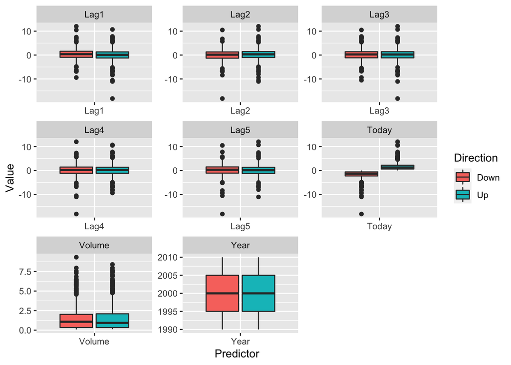

```r
# generate boxplots to see if there appears to be a difference in predictor mean between 'up' and 'down'

# https://www.r-graph-gallery.com/265-grouped-boxplot-with-ggplot2.html#:~:text=A%20grouped%20boxplot%20is%20a,called%20in%20the%20fill%20argument.

# pivot data to long form
weekly.long <- Weekly %>%
  pivot_longer(-Direction, names_to = "Predictor", values_to = "Value")
weekly.long <- weekly.long[, c("Predictor", "Direction", "Value")]

# create facet of plots
boxplot <- ggplot(weekly.long, aes(x=Predictor, y=Value, fill=Direction)) +
  geom_boxplot() +
  facet_wrap(~Predictor, scales = "free")
boxplot
```

(b) Use the full data set to perform a logistic regression with Direction as the response and the five lag variables plus Volume as predictors. Use the summary function to print the results. Do any of the predictors appear to be statistically significant? If so, which ones?

```r
weekly.log.fit.today <- glm(Direction ~ -Year -Volume, data = Weekly, family = binomial)
summary(weekly.log.fit.today)
```

```
##
## Call:
## glm(formula = Direction ~ -Year - Volume, family = binomial,
##     data = Weekly)
##
## Deviance Residuals:
##    Min      1Q  Median      3Q     Max
## -1.274  -1.274   1.084   1.084   1.084
##
## Coefficients:
##             Estimate Std. Error z value Pr(>|z|)
## (Intercept)  0.22314    0.06098   3.659 0.000253 ***
## ---
## Signif. codes:  0 '***' 0.001 '**' 0.01 '*' 0.05 '.' 0.1 ' ' 1
##
## (Dispersion parameter for binomial family taken to be 1)
##
##     Null deviance: 1496.2  on 1088  degrees of freedom
## Residual deviance: 1496.2  on 1088  degrees of freedom
## AIC: 1498.2
##
## Number of Fisher Scoring iterations: 3
```

Note that we did first did a glm fit that includes the ‘Today’ variable, just to see what’s going on with the obvious difference shown in this variable in the box plots. But this model threw an error, (“fitted probabilities numerically 0 or 1 occurred”) which indicates that there is a 100% correlation between the predictor and the outcome class. In hindsight, this makes sense, because the Direction class is just a classification that’s *based* on the Today predictor.

Other than the wonky Today predictor, there appears to be a significant positive relationship between the Lag2 (the market change two days before), and the outcome:

```r
weekly.log.fit <- glm(Direction ~ . -Year -Today -Volume, data = Weekly, family = binomial)
summary(weekly.log.fit)
```

```
##
## Call:
## glm(formula = Direction ~ . - Year - Today - Volume, family = binomial,
##     data = Weekly)
##
## Deviance Residuals:
##     Min       1Q   Median       3Q      Max
## -1.7297  -1.2574   0.9939   1.0868   1.4671
##
## Coefficients:
##             Estimate Std. Error z value Pr(>|z|)
## (Intercept)  0.23029    0.06203   3.712 0.000205 ***
## Lag1        -0.04010    0.02635  -1.522 0.128125
## Lag2         0.06015    0.02674   2.249 0.024503 *
## Lag3        -0.01508    0.02664  -0.566 0.571381
## Lag4        -0.02677    0.02643  -1.013 0.311082
## Lag5        -0.01349    0.02636  -0.512 0.608894
## ---
## Signif. codes:  0 '***' 0.001 '**' 0.01 '*' 0.05 '.' 0.1 ' ' 1
##
## (Dispersion parameter for binomial family taken to be 1)
##
##     Null deviance: 1496.2  on 1088  degrees of freedom
## Residual deviance: 1486.7  on 1083  degrees of freedom
## AIC: 1498.7
##
## Number of Fisher Scoring iterations: 4
```

3. Compute the confusion matrix and overall fraction of correct predictions. Explain what the confusion matrix is telling you about the types of mistakes made by logistic regression.

```r
# set training and test indexes
# create a vector of logical values that label each obs as either before (T) or during and after (F) 2005
train <- (Weekly$Year < 2005)
test <- (Weekly$Year >= 2005)
# use this to create a subset of training data (pre-2005) and test data (2005 and after)
Weekly.test <- Weekly[test,]
Weekly.train <- Weekly[train,]
# create a single-var vector of test predictions from this data
Weekly.test.outcomes <- Weekly.test$Direction
# create a logistical model with the training data
Weekly.glm.train.fit <- glm(Direction ~ . -Year -Today -Volume, data = Weekly.train, family = binomial)
summary(Weekly.glm.train.fit)
```

```
##
## Call:
## glm(formula = Direction ~ . - Year - Today - Volume, family = binomial,
##     data = Weekly.train)
##
## Deviance Residuals:
##     Min       1Q   Median       3Q      Max
## -1.5541  -1.2580   0.9809   1.0814   1.4589
##
## Coefficients:
##             Estimate Std. Error z value Pr(>|z|)
## (Intercept)  0.25322    0.07433   3.407 0.000658 ***
## Lag1        -0.03146    0.03431  -0.917 0.359206
## Lag2         0.04840    0.03453   1.402 0.161007
## Lag3        -0.01941    0.03446  -0.563 0.573185
## Lag4        -0.03776    0.03447  -1.095 0.273322
## Lag5        -0.05856    0.03426  -1.709 0.087421 .
## ---
## Signif. codes:  0 '***' 0.001 '**' 0.01 '*' 0.05 '.' 0.1 ' ' 1
##
## (Dispersion parameter for binomial family taken to be 1)
##
##     Null deviance: 1065.3  on 775  degrees of freedom
## Residual deviance: 1058.0  on 770  degrees of freedom
## AIC: 1070
##
## Number of Fisher Scoring iterations: 4
```

Interesting - if we split the data into test and training, the relationship with Lag2 loses significance. Let’s run some predictions now with our test data set:

[output not shown]

```
## [1] 0.4440895
```

```
## [1] 0.8794326
```

```
## [1] 0.9127907
```

Good lord, these are some terrible test results. Let’s try improving it …

4. Now fit the logistic regression model using a training data period from 1990 to 2008, with Lag2 as the only predictor. Compute the confusion matrix and the overall fraction of correct predictions for the held out data (that is, the data from 2009 and 2010).

```r
# create a vector of logical values that label each obs as either before (T) or during and after (F) 2005
train.2008 <- (Weekly$Year <= 2008)
test.2008 <- (Weekly$Year > 2008)
# use this to create a subset of training data and test data
Weekly.test.2008 <- Weekly[test.2008,]
Weekly.train.2008 <- Weekly[train.2008,]
# create a single-var vector of test predictions from this data
Weekly.test.2008.outcomes <- Weekly.test.2008$Direction
# create a logistical model with the training data
Weekly.glm.train.2008.fit <- glm(Direction ~ Lag2, data = Weekly.train.2008, family = binomial)
summary(Weekly.glm.train.2008.fit)
```

```
##
## Call:
## glm(formula = Direction ~ Lag2, family = binomial, data = Weekly.train.2008)
##
## Deviance Residuals:
##    Min      1Q  Median      3Q     Max
## -1.536  -1.264   1.021   1.091   1.368
##
## Coefficients:
##             Estimate Std. Error z value Pr(>|z|)
## (Intercept)  0.20326    0.06428   3.162  0.00157 **
## Lag2         0.05810    0.02870   2.024  0.04298 *
## ---
## Signif. codes:  0 '***' 0.001 '**' 0.01 '*' 0.05 '.' 0.1 ' ' 1
##
## (Dispersion parameter for binomial family taken to be 1)
##
##     Null deviance: 1354.7  on 984  degrees of freedom
## Residual deviance: 1350.5  on 983  degrees of freedom
## AIC: 1354.5
##
## Number of Fisher Scoring iterations: 4
```

```r
# generate new probs
Weekly.test.2008.probs <- predict(Weekly.glm.train.2008.fit, newdata = Weekly.test.2008, type="response")
# create factor-based vector of predictions ...
Weekly.test.2008.preds <- rep("Down", length(Weekly.test.2008.probs))
Weekly.test.2008.preds[Weekly.test.2008.probs > 0.5] <- "Up"
Weekly.test.2008.preds[Weekly.test.2008.probs <= 0.5] <- "Down"
# then do confusion matrix
conf.matrix <- table(Weekly.test.2008.preds, Weekly.test.2008.outcomes)
conf.matrix
```

```
##                       Weekly.test.2008.outcomes
## Weekly.test.2008.preds Down Up
##                   Down    9  5
##                   Up     34 56
```

```r
# overall test error rate
mean(Weekly.test.2008.preds != Weekly.test.2008.outcomes)
```

```
## [1] 0.375
```

```r
# false positive rate [false pos predictions / (false pos + true neg) predictions]
alpha <- conf.matrix[2,1]/(conf.matrix[1,1]+conf.matrix[2,1])
alpha
```

```
## [1] 0.7906977
```

```r
# false negative rate [false neg predictions / (false neg + true pos) predictions]
power <- 1 - conf.matrix[1,2]/(conf.matrix[1,2]+conf.matrix[2,2])
power
```

```
## [1] 0.9180328
```

It appears we reduced the test error rate by quite a bit - mainly by reducing the false positive rate, but it’s still very high. It doesn’t seem like logistical regression is the way to go for this particular model. We should try some that are less prone to bias.